# A new approach to extrapolation: blended survival curves

Zhaojing Che | Department of Statistical Science | University College London

# Motivating case study

Here is an example about the technical implementation (including relevant `R` code) of the blended model. Firstly, the “blending” idea is to consider two separate processes to describe the long-term horizon survival; one is to use a flexible model (e.g. Cox semi-parametric) to fit as well as possible the observed data, and the other is a parametric model encoding assumptions on the expected behaviour of underlying long-term survival. Then importantly, the two are “blended” into a single survival curve that is identical with the flexible model over the range of observed times and increasingly similar to the parametric model over the extrapolation period.

## Install and load required R packages

We will use two R packages:

- `INLA` for computing observed survival estimates based on internal data
- `survHE` for computing external survival estimates with expert judgement

Install the packages

```r
# For Windows:
install.packages("survHE",
                   repos=c("http://www.statistica.it/gianluca/R",
                             "https://cran.rstudio.org",
                         "https://inla.r-inla-download.org/R/stable"),
                   dependencies=TRUE)

install.packages("INLA",
                 repos=c(getOption("repos"),
                         INLA="https://inla.r-inla-download.org/R/stable"),
                 dep=TRUE)
```

Load the packages

```r
library(survHE)
library(INLA)
```

## Example dataset (TA174)

We will use CLL-8 trial data in NICE technology appraisal TA174, which compares rituximab in combination with fludarabine and cyclophosphamide (FCR) to fludarabine and cyclophosphamide (FC) for the first-line treatment of chronic lymphocytic leukemia. Here we make the arm FCR as the example.

```r
load("../Data/ta174_FCR.Rdata")
head(dat_FCR)
```

```
## # A tibble: 6 × 8
##   patid treat  prog death prog_t death_t prog_ty death_ty
##   <int> <int> <int> <int>  <dbl>   <dbl>   <dbl>    <dbl>
## 1     1     1     1     0 32.0    32      2.67     2.67
## 2     2     1     1     0 30.6    30.6    2.55     2.55
## 3     3     1     1     0 27.9    28      2.33     2.33
## 4     8     1     1     0 29.8    30      2.48     2.5
## 5    10     1     1     1  0.173   0.458  0.0144   0.0382
## 6    11     1     1     1  1.27    1.57   0.105    0.131
```

- `patid`: Patient ID
- `treat`: Treatment arm 1 = FCR
- `prog` : Progression status 0 = censored, 1 = progression
- `death`: Death status 0 = censored, 1 = dead
- `prog_t`: Progression time in months
- `death_t`: Survival time in months
- `prog_ty`: Progression time in years
- `death_ty`: Survival time in years

Before starting the analysis, we need to source a R script that contains all functions required in the following components firstly.

```r
source("../Scripts/Functions.R", local = knitr::knit_global())
```

Details of the functions are described in another chapter *Useful functions*.

## Observed time period

### Internal curve: piecewise exponential model

To provide the best fit possible and a good level of flexibility, we will use a Cox semi-parametric model with piecewise constant hazard. The hazard is modeled as
$$h(t) = \text{exp}(\lambda_{k}); \quad t\in (u_{k-1}, u_k], \quad k = 1, \ldots, K$$
Hence the time axis is partitioned into $K$ intervals using $0<u_1<u_2<\ldots<u_K<\infty$ and variables $\mathbf{\lambda} = (\lambda_1, \ldots, \lambda_K)$ are assumed to a prior with random walks (RW) of order one (or two).

The `surv_est_inla` function creates internal survival curves ($S_{obs}$) based on the model fitted to the observed data using Bayesian INLA approach. Below, we set the time horizon from 0 to 180 months (15 years), during which intervals are constructed for every five months in the option `cutpoints`.

```r
obs_Surv <- surv_est_inla(data = dat_FCR,
                          cutpoints = seq(0,180, by =5))

names(obs_Surv)
```

```
## [1] "time"  "S_obs" "KM"
```

Two key components of `obs_Surv` object that will be used to plot survival curves:

- `time`: times used to create the survival curves.
- `S_obs`: survival probabilities corresponding to elements of `time`

Figure 1 shows that the model achieves a feasible fit to the observed data, but does not generate a credible extrapolation. It suggests over 50% survival at 15 years (end of the green curve), which is in stark contrast with expert estimates, suggesting instead that only 1.3% of the cohort would be likely to survive beyond that time.

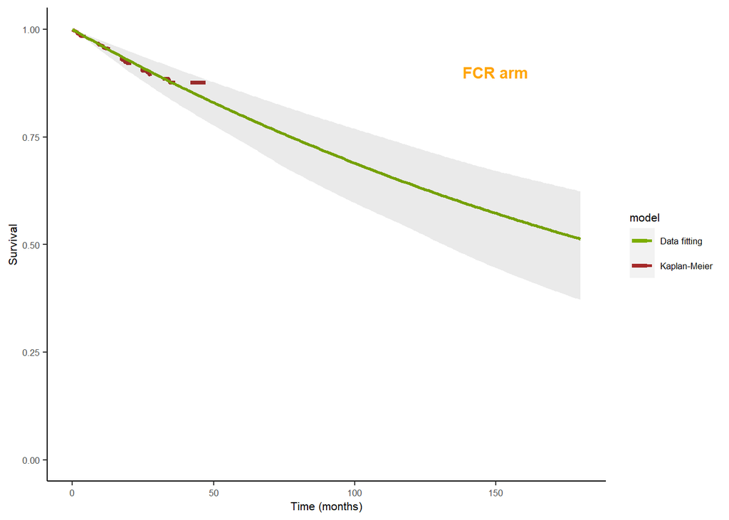

Figure 1: Survival estimates of the FCR arm based on the piecewise exponential model fitted to the observed data

## Unobserved time period

### External curve: using expert judgement

To produce a reasonable and realistic estimate for the long-term survival, we consider an external curve that is not informed by the observed data, but driven by the evidence from a different data source instead. Ideally, we can access matched long-term data from a relevant study, possibly of an observational nature, such as a registry or a cohort study, yet it is not always the case. Here we focus on a more general situation when only subjective knowledge is available, typically in the form of expert elicitation.

The `ext_surv_est` function creates external survival curves ($S_{ext}$) encoding external assumptions from expert opinion. In this motivating example, there is a strong opinion that approximately 1.3% of the cohort would be alive beyond 15 years, hence we identify the lifetime horizon as 15 years (180 months) (Roche Products Limited 2008). Then if it is assumed that the survival probability at 12 years (`t_info = 144`) should be approximately 5% (`S_info = 0.05`) based on previous experience, we can use following code:

```r
ext_Surv <- ext_surv_est(t_info = 144, S_info = 0.05,
                         T_max = 180,
                         times_est = seq(0, 180), distr = "gom")

names(ext_Surv)
```

```
## [1] "S_ext"
```

## Blended estimate

Given both internal and external curves over the whole time-horizon, we can compute the blended estimate based on a weight function $\pi(t; \alpha, \beta, a, b)$.

Here we set the blending interval $[48, 150]$ and $Beta(3, 3)$. The object `weight` contains the values of weight allocated to the external survival over the time.

```r
blending_interval <- list(min = 48, max = 150)
beta_params <- list(alpha = 3, beta = 3)

tp <- seq(0, 180)

# parameters for the weight function
wt_par <- list(a = blending_interval$min, b = blending_interval$max,
               shape1 = beta_params$alpha, shape2 = beta_params$beta)

weight <- with(wt_par,
               pbeta((tp - a)/(b - a), shape1, shape2))
```

The blended survival curve is simply obtained as
$$S_{ble}(t) = S_{obs}(t)^{1-\pi(t; \alpha, \beta, a, b)}\times S_{ext}(t)^{\pi(t;\alpha, \beta, a, b)}$$

```r
n_sim <- ncol(ext_Surv$S_ext)

ble_Surv <- matrix(NA, nrow = 180 + 1, ncol = n_sim)

for (i in seq_len(n_sim)) {
  ble_Surv[, i] <-
    obs_Surv$S_obs[, i]^(1 - weight) * ext_Surv$S_ext[, i]^weight
}
```

Figure 2 shows the blended survival estimate of the FCR arm driven by internal and external curve over the whole time-horizon. Below represents the result of one assumption about the blending operation, and different scenarios can be tested by changing the values of the parameters (`wt_par`) associated with the weight function.

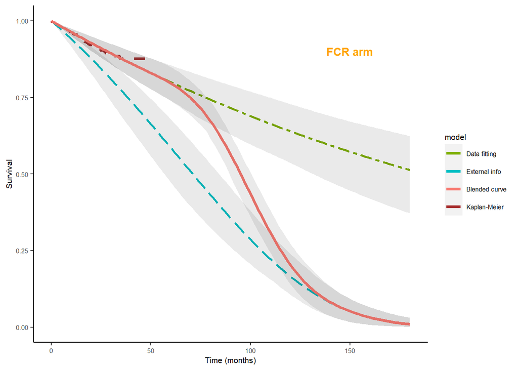

Figure 2: Blended survival curve based on short-term data and external information for FCR arm

# References

Roche Products Limited. 2008. “Rituximab for the 1st Line Treatment of Chronic Lymphocytic Leukaemia.”